# Which College is Best for You? Part 2

Michael L. Thompson

January 17, 2016, rev. Oct. 25, 2017

# Introduction

This is a followup to my first script [“Which College is Best for You?_“](https://www.kaggle.com/apollostar/d/kaggle/college-scorecard/which-college-is-best-for-you).

Ben Hamner suggested in his comments to that first script that I write a script allowing anyone to specify his or her student profile right at the top. In this way the script might be more appealing for other folks to fork and play with it themselves. Good advice!

So here it is.

One thing though,… Using RStudio on this R Markdown file, you can click on “Chunks–>Run All” to save the variables in the global environment. Then it won’t have to re-process the database every time you make a change to the student profile and re-run it each time with “Chunks–>Run All” to generate a new top schools list.

## By the Way…

I’ve now added an R Shiny GUI and made it into a browser-based app: [“Best Colleges for You”](https://thompsonml.shinyapps.io/BestCollegeApp/)!

# Specify Your Student Profile

```r
Case <- list(studentProfile = list(
  dependent = TRUE,           # c(TRUE,FALSE)
  ethnicity = 'white',        # c('white','black','hispanic','asian')
  gender    = 'male',       # c('male','female')
  age       = 'le24',         # c('le24','gt24') (years of age)
  income    = 'gt30Kle110K',       # c('le30K','gt30Kle110K','gt110K') ($US)
  earnings  = 'gt110K',       # c('le30K','gt30Kle75K','gt75Kle110K','gt110K') ($US)
  sat       = 'gt1000le1200',       # c('le800','gt800le1000','gt1000le1200','gt1200le1400','gt1400')
  fafsa     = 'fsend_3',      # c('fsend_1','fsend_2','fsend_3','fsend_4','fsend_5')
  discipline= 'ComputerInformation',  # See below.
  region    = 'GreatLakes',      # See below for which states in which regions.
  locale    = 'CityMidsize',    # See below.
  traits    = list(           # See below.
    Risk      = 'M',
    Vision    = 'M',
    Breadth   = 'M',
    Challenge = 'M') # Must be in order; only 'L','M','H' valid.
)
)
```

(Note: The comments show the only valid values for each field. The `fafsa` field refers to how many schools FAFSA form was sent to. Values `'fsend_1'` to `'fsend_4'` correspond to 1 to 4 schools, resp., and `'fsend_5'` refers to 5 or more schools. Values for `income`, `earnings` and `sat` contain `"le"` meaning “less than or equal to” and `"gt"` meaning “greater than”. The `"K"` in the `income` and `earnings` values means “thousand”. So `'gt30Kle110K'` means “greater than $30,000 and less than or equal to $110,00”.

The fields with “See below.” are explained in section *“Explanation of Valid Entries for Student Profile”* at the end of the file.)

# Setup the Data & Model

The next chunk loads the college database and defines necessary data structures and functions to implement the model.

```r
#================================================================
# RUN THE SETUP FUNCTION:
DataSpec <- make_DataSpec()
DataSpec$utility <- utility

#================================================================

# # Assign setup variables to objects in current environment:
# for( vnm in names(setupResult )){
#   eval(parse(text=sprintf('%s = setupResult$%s',vnm,vnm)))
# }
```

# Here are *Your* Top Colleges

Apply the model to get your `ntop` colleges:

```r
# ENTER N, for top-N colleges:
Case$ntop <- 20
Case$studentProfile$beta <- getParameters(Case$studentProfile, DataSpec$propertyMap)
Case <- studentCaseStudy(Case, DataSpec, verbose = FALSE, ntop = Case$ntop)

# # Check-in on some select schools: selectSchools <- paste(c('Massachusetts
# Institute of Technology', 'California Institute of Technology',
# 'Princeton', 'Yale', 'Harvard', 'Stanford', 'Duke', 'Vanderbilt',
# 'Berkeley', 'Northwestern U', 'Princeton', 'Cornell U'),collapse='|')
# Case$BF %>% filter(grepl(selectSchools,labels)) %$% { tmp<-t(.[-1]);
# dimnames(tmp)<-list(names(.)[-1],gsub(' | University|nstitute of
# |echnology|ifornia|assachusetts|of','',labels)); tmp } %>% round(2)
```

Display the results:

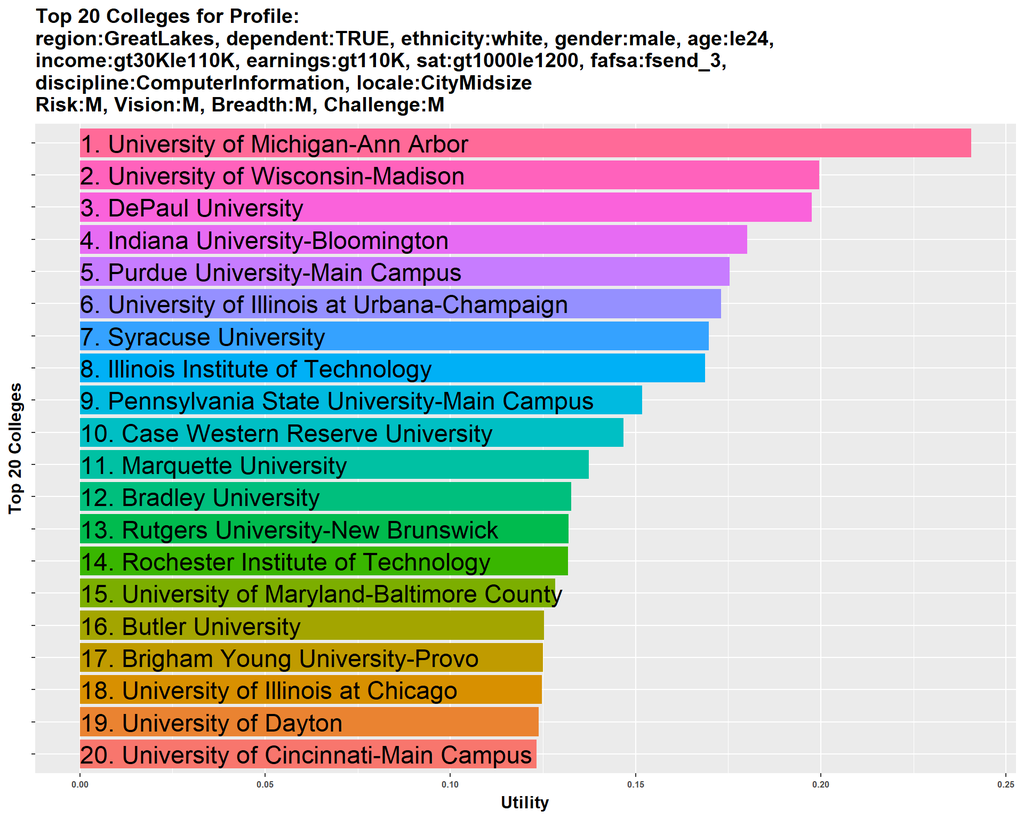

```r
plotTopN(Case,plot.it = TRUE)
```

Display a bit more output to help explain why those are the top schools.

The factor `prior` refers to the contribution due to size of school in terms of undergraduate enrollment (database field `"UGDS"`).

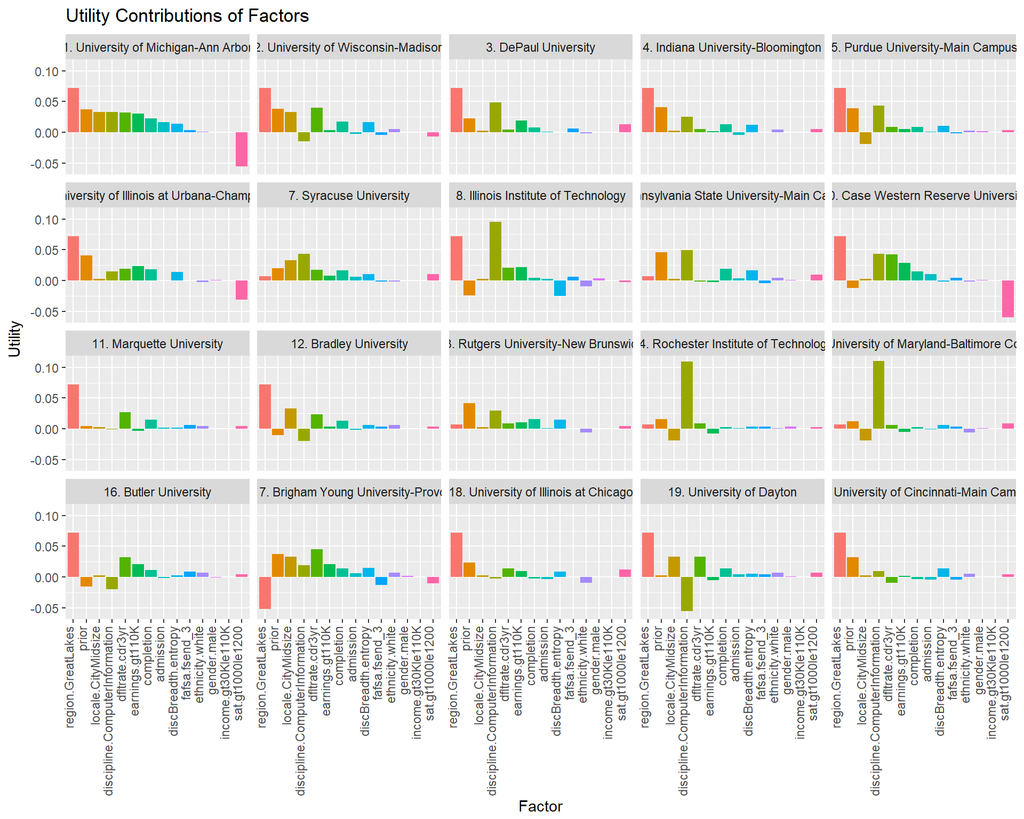

```r
# Plot the partworth contributions to the utility for each of the top schools.
plotContributions(Case,plot.it = TRUE)
```

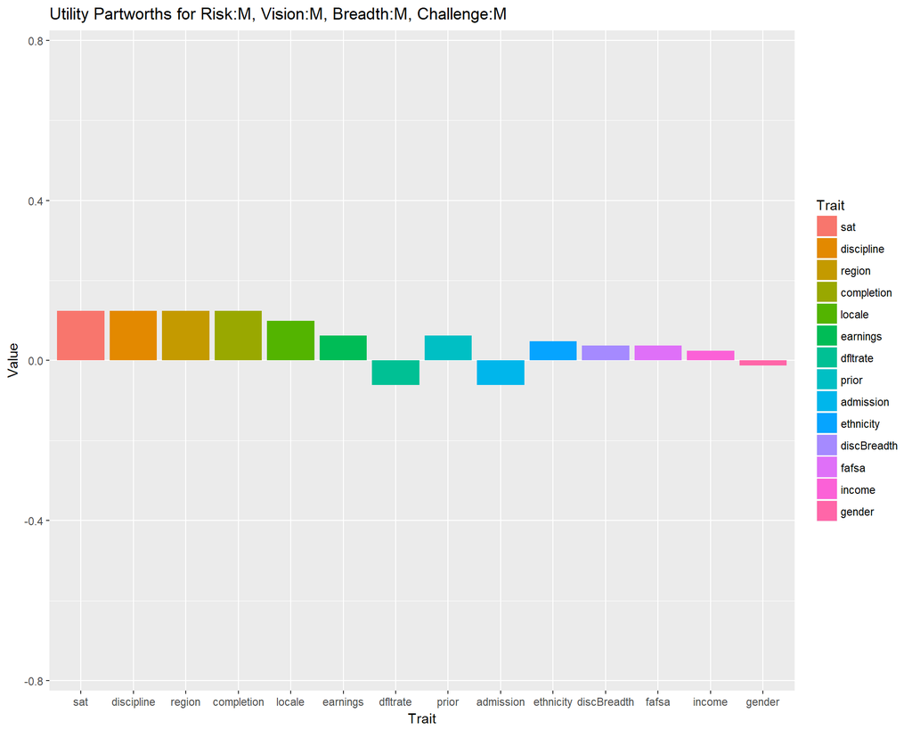

```r
# Show the partworth (utility function parameters):
plotBeta(Case$studentProfile$beta,Case$studentProfile)
```

# How About a Road-Trip to Your Top Schools?!

I’ve copied idea and code snips from Tad Dallas’s script on Kaggle.com:

[interactive chart not shown]

# Sensitivity of Your Top Schools to Changes in Your Profile

Perform sensitivity analysis on your profile factors.

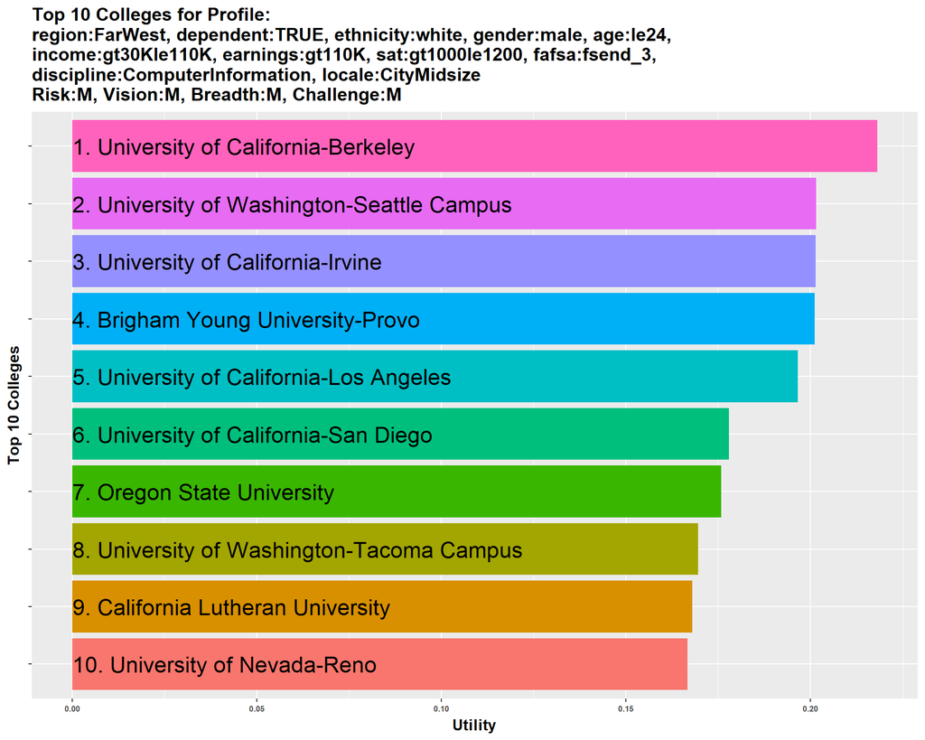

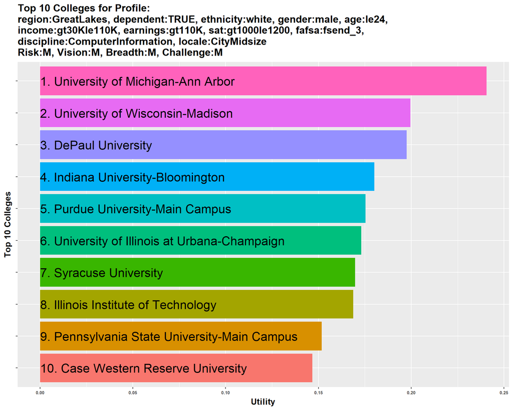

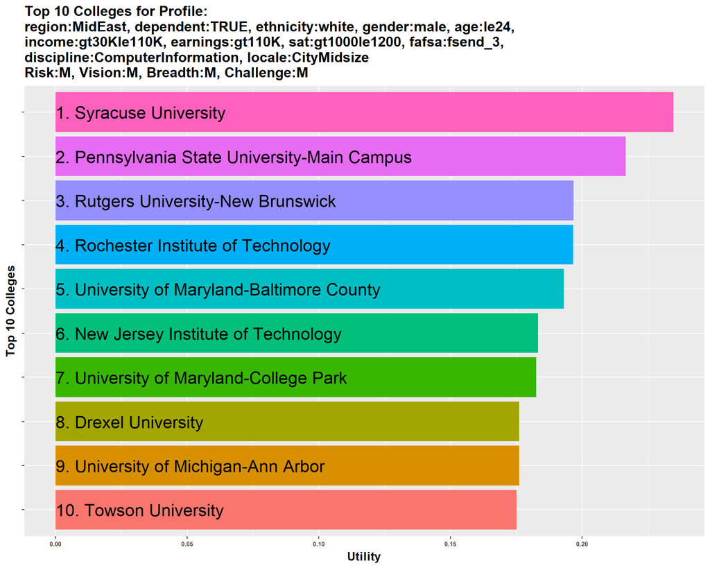

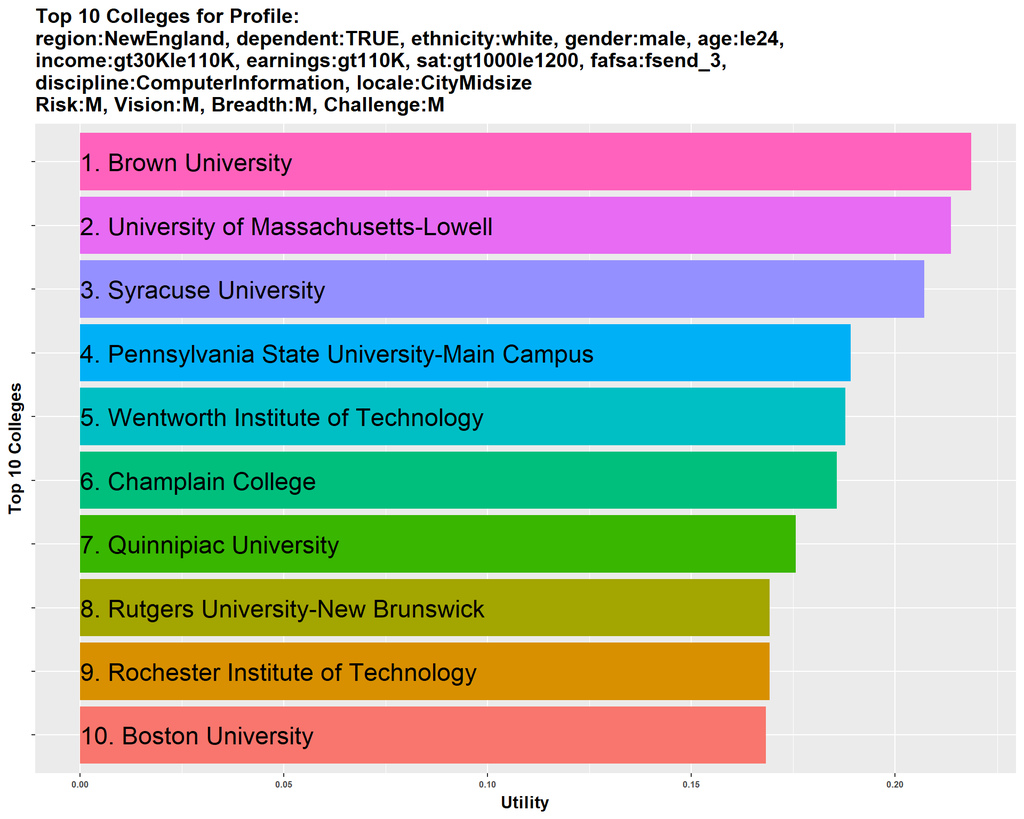

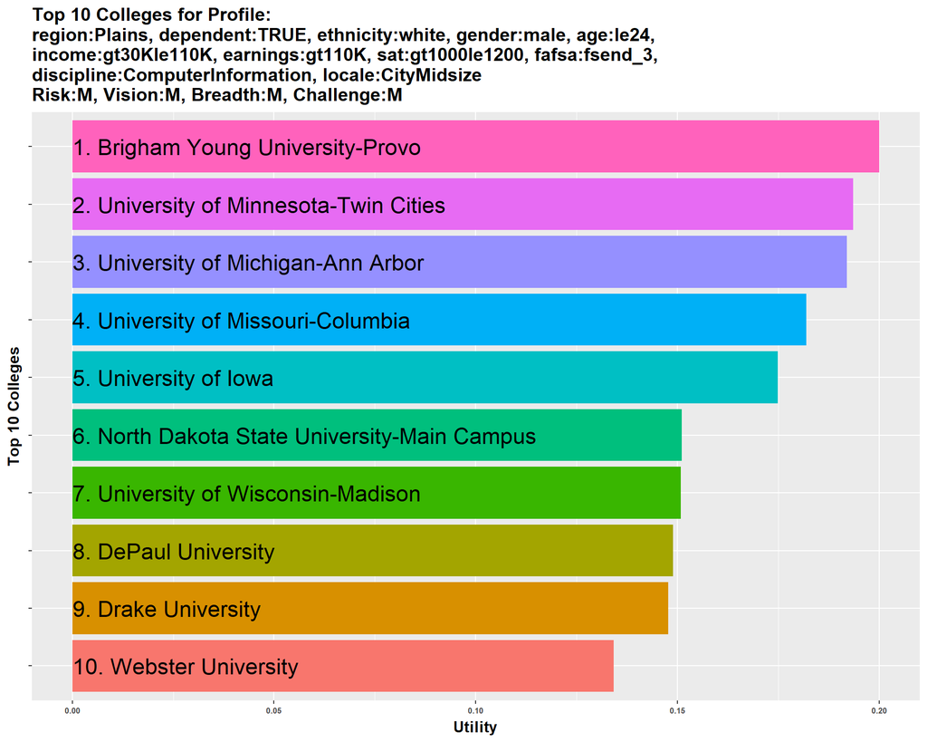

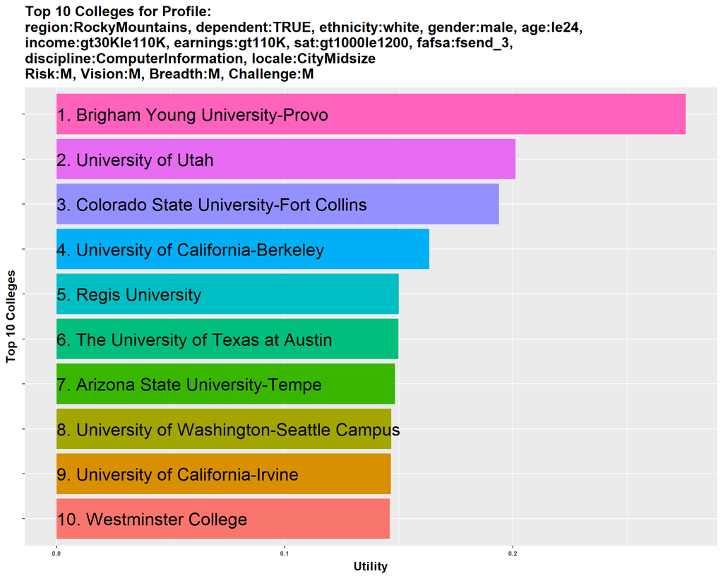

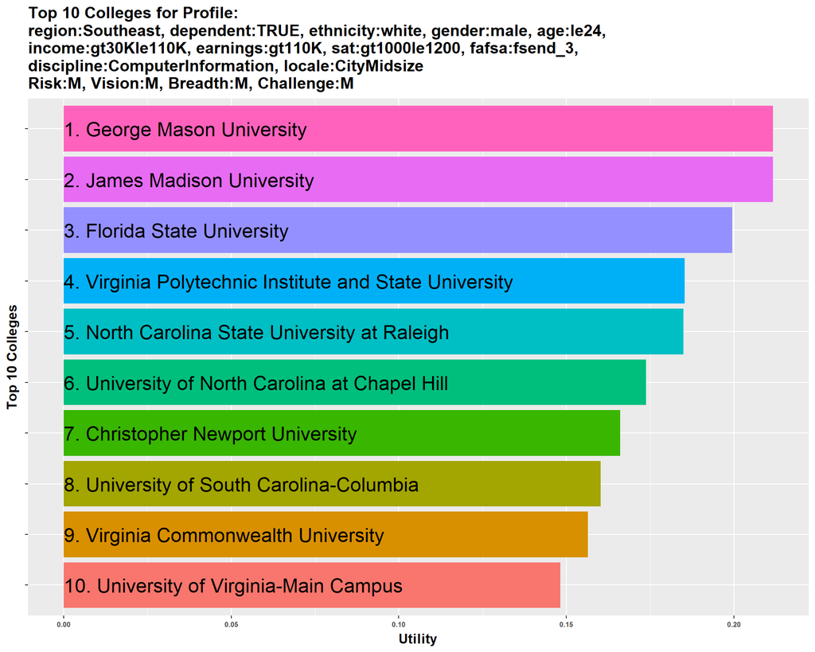

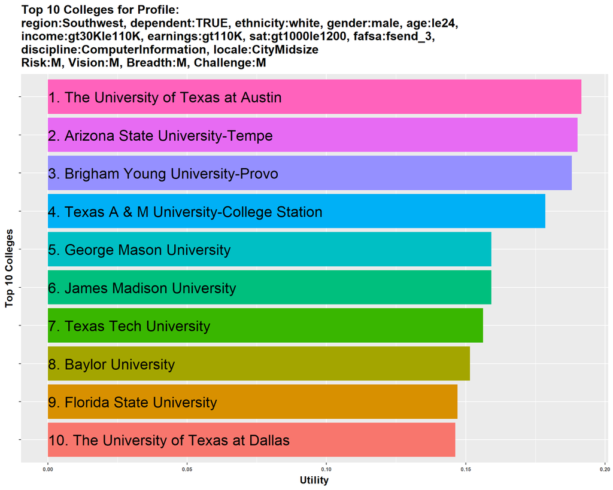

```r
# Sweep region
sweepVariable <- "region"
case0 <- Case
stdtProf0 <- case0$studentProfile
pmap <- DataSpec$propertyMap[sweepVariable]
maxcnt <- length(pmap[[sweepVariable]])
sensResults <- sensitivity(stdtProf0, pmap, case0, DataSpec, maxcnt = maxcnt,
    plot.it = FALSE)
print(sensResults$grobList)
```

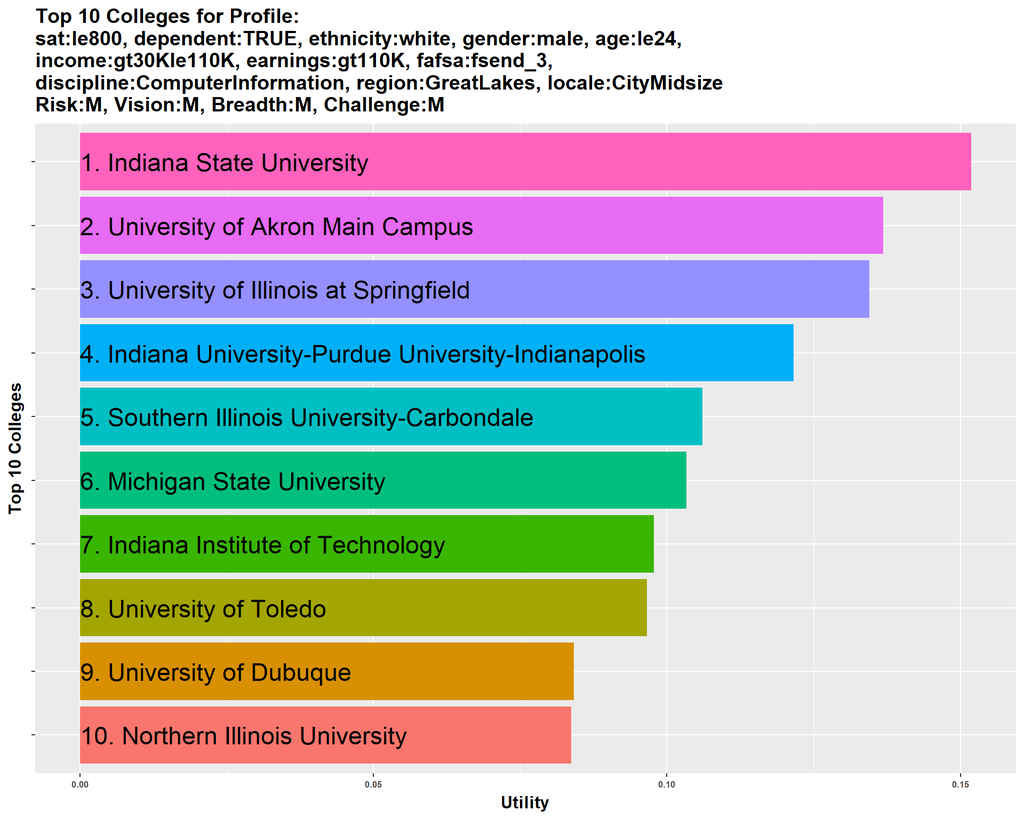

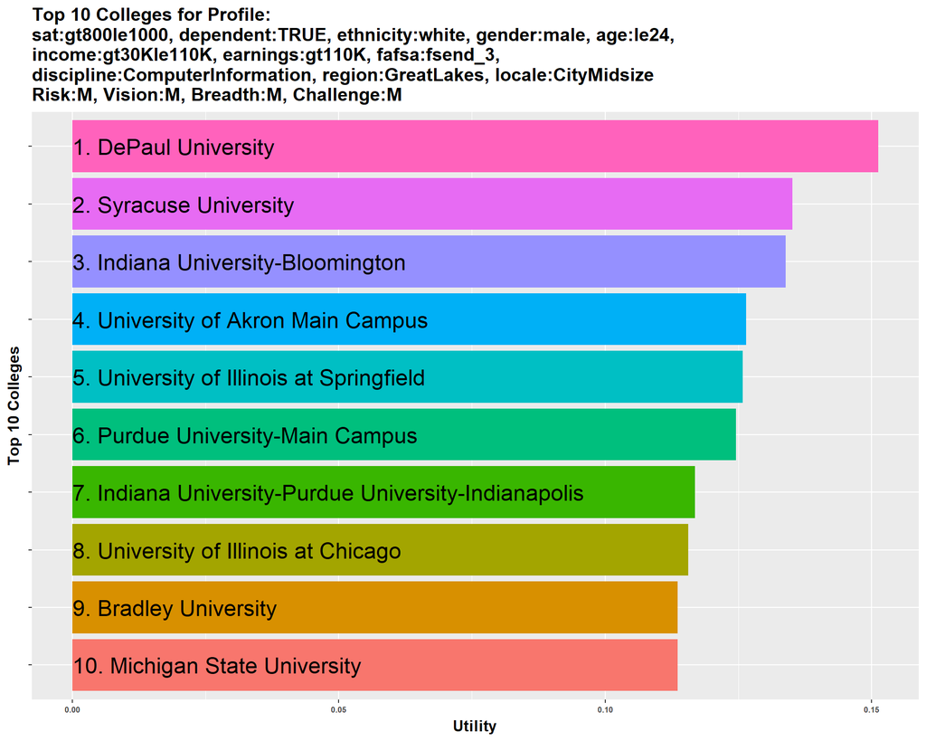

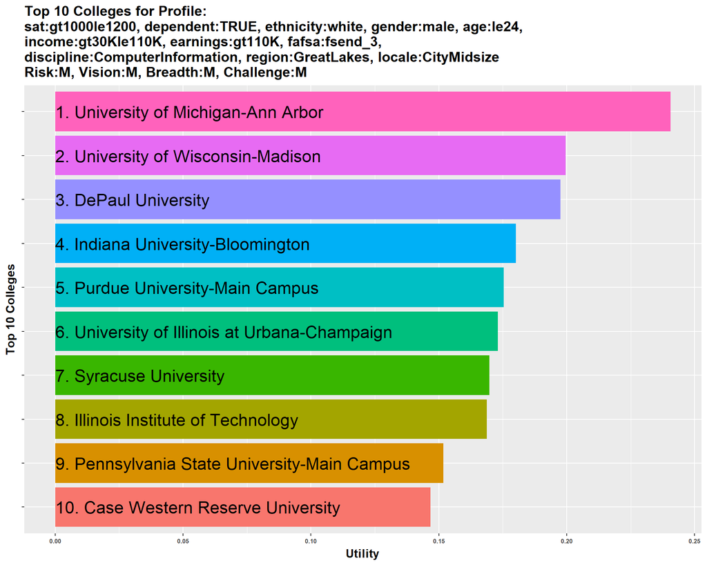

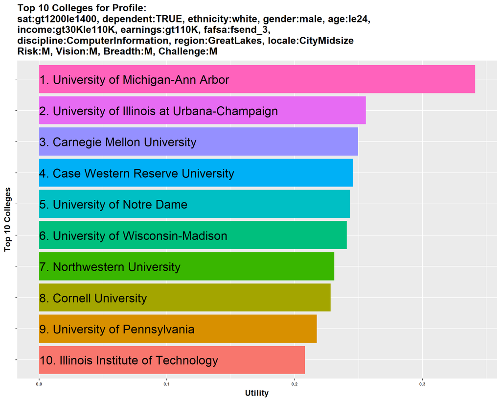

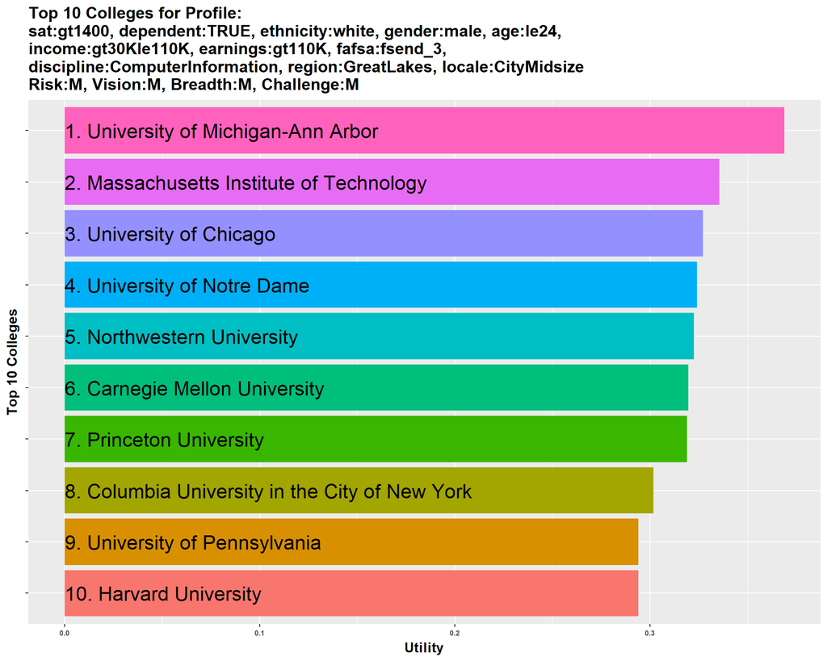

```r
# This is how to sweep over SAT:
sweepVariable <- "sat"
case0 <- Case
stdtProf0 <- case0$studentProfile
pmap <- DataSpec$propertyMap[sweepVariable]
maxcnt <- length(pmap[[sweepVariable]])
sensResults <- sensitivity(stdtProf0, pmap, case0, DataSpec, maxcnt = maxcnt,
    plot.it = FALSE)
print(sensResults$grobList)
```

```r
# sweepVariable <- 'locale' stdtProf0 <- studentProfile pmap <-
# propertyMap[sweepVariable] maxcnt <- length(pmap[[sweepVariable]])
# sensResults <-
# sensitivity(stdtProf0,pmap,Case,DataSpec,maxcnt=maxcnt,plot.it=FALSE)
# print(sensResults$grobList)

# # This is how to sweep over a subset of disciplines: stdtProf0 <-
# Case$studentProfile pmap <- DataSpec$propertyMap[c('discipline')]
# pmap$discipline <-
# pmap$discipline[c('ComputerInformation','BiologicalBiomedical','HealthProfessions','PhysicalSciences','MathematicsStatistics')]
# maxcnt <- pmin(7,length(pmap$discipline)) sensResults <-
# sensitivity(stdtProf0,pmap,Case,DataSpec,maxcnt=maxcnt,plot.it=FALSE)
# print(sensResults$grobList)

# # This is how to sweep over a behavioral trait: stdtProf0 <-
# Case$studentProfile ntop <- 10 for(lvl in c('L','M','H')){
# stdtProf0$traits$Risk <- lvl stdtProf0$beta <-
# getParameters(stdtProf0,DataSpec$propertyMap) case0 <-
# list(studentProfile=stdtProf0,ntop=ntop) case0 <-
# studentCaseStudy(case0,DataSpec,verbose=FALSE,ntop=ntop)
# plotTopN(caseResult = case0,plot.it = TRUE) }
```

# Explanation of Valid Entries for Student Profile

The following selections show what entries are valid for the student’s `region`, `locale`, `discipline` and behavioral traits.

## Valid Regions

Valid region names to choose for your student profile `region` property are shown in column *Region* of the table below; and states in each region are listed in the *States* column:

|  | Region | States |
| --- | --- | --- |
| 1 | FarWest | AK,CA,HI,NV,OR,WA |
| 2 | GreatLakes | IL,IN,MI,OH,WI |
| 3 | MidEast | DE,DC,MD,NJ,NY,PA |
| 4 | NewEngland | CT,ME,MA,NH,RI,VT |
| 5 | Plains | IA,KS,MN,MO,NE,ND,SD |
| 6 | RockyMountains | CO,ID,MT,UT,WY |
| 7 | Southeast | AL,AR,FL,GA,KY,LA,MS,NC,SC,TN,VA,WV |
| 8 | Southwest | AZ,NM,OK,TX |

## Valid Locales

Valid locale names to choose for your student profile `locale` property are shown in column *Locale* of the table below:

|  | Locale | Description |
| --- | --- | --- |
| 1 | Rural | Rural: Remote (rural territory more than 25 miles from an urbanized area and more than 10 miles from an urban cluster) |
| 2 | Rural | Rural: Distant (rural territory more than 5 miles but up to 25 miles from an urbanized area or more than 2.5 and up to 10 miles from an urban cluster) |
| 3 | Rural | Rural: Fringe (rural territory up to 5 miles from an urbanized area or up to 2.5 miles from an urban cluster) |
| 4 | TownRemote | Town: Remote (in urban cluster more than 35 miles from an urbanized area) |
| 5 | TownDistant | Town: Distant (in urban cluster more than 10 miles and up to 35 miles from an urbanized area) |
| 6 | SuburbSmallMid | Town: Fringe (in urban cluster up to 10 miles from an urbanized area) |
| 7 | SuburbSmallMid | Suburb: Small (outside principal city, in urbanized area with population less than 100,000) |
| 8 | SuburbSmallMid | Suburb: Midsize (outside principal city, in urbanized area with population of at least 100,000 but less than 250,000) |
| 9 | SuburbLarge | Suburb: Large (outside principal city, in urbanized area with population of 250,000 or more) |
| 10 | CitySmall | City: Small (population less than 100,000) |
| 11 | CityMidsize | City: Midsize (population of at least 100,000 but less than 250,000) |
| 12 | CityLarge | City: Large (population of 250,000 or more) |

## Valid Academic Disciplines

Valid academic disciplines to choose for your student profile `discipline` property are shown in column *discName* of the table below:

|  | LABEL | discName |
| --- | --- | --- |
| 1 | Agriculture, Agriculture Operations, and Related Sciences | AgricultureAgriculture |
| 2 | Architecture and Related Services | ArchitectureRelated |
| 3 | Area, Ethnic, Cultural, Gender, and Group Studies | AreaEthnic |
| 4 | Biological and Biomedical Sciences | BiologicalBiomedical |
| 5 | Business, Management, Marketing, and Related Support Services | BusinessManagement |
| 6 | Communication, Journalism, and Related Programs | CommunicationJournalism |
| 7 | Communications Technologies/Technicians and Support Services | CommunicationsTechnologies |
| 8 | Computer and Information Sciences and Support Services | ComputerInformation |
| 9 | Construction Trades | ConstructionTrades |
| 10 | Education | Education |
| 11 | Engineering | Engineering |
| 12 | Engineering Technologies and Engineering-Related Fields | EngineeringTechnologies |
| 13 | English Language and Literature/Letters | EnglishLanguage |
| 14 | Family and Consumer Sciences/Human Sciences | FamilyConsumer |
| 15 | Foreign Languages, Literatures, and Linguistics | ForeignLanguages |
| 16 | Health Professions and Related Programs | HealthProfessions |
| 17 | History | History |
| 18 | Homeland Security, Law Enforcement, Firefighting and Related Protective Services | HomelandSecurity |
| 19 | Legal Professions and Studies | LegalProfessions |
| 20 | Liberal Arts and Sciences, General Studies and Humanities | LiberalArts |
| 21 | Library Science | LibraryScience |
| 22 | Mathematics and Statistics | MathematicsStatistics |
| 23 | Mechanic and Repair Technologies/Technicians | MechanicRepair |
| 24 | Military Technologies and Applied Sciences | MilitaryTechnologies |
| 25 | Multi/Interdisciplinary Studies | MultiInterdisciplinary |
| 26 | Natural Resources and Conservation | NaturalResources |
| 27 | Parks, Recreation, Leisure, and Fitness Studies | ParksRecreation |
| 28 | Personal and Culinary Services | PersonalCulinary |
| 29 | Philosophy and Religious Studies | PhilosophyReligious |
| 30 | Physical Sciences | PhysicalSciences |
| 31 | Precision Production | PrecisionProduction |
| 32 | Psychology | Psychology |
| 33 | Public Administration and Social Service Professions | PublicAdministration |
| 34 | Science Technologies/Technicians | ScienceTechnologies |
| 35 | Social Sciences | SocialSciences |
| 36 | Theology and Religious Vocations | TheologyReligious |
| 37 | Transportation and Materials Moving | TransportationMaterials |
| 38 | Visual and Performing Arts | VisualPerforming |

## Explanation of Behavioral Traits

Trait level has 4 types with impact on properties as follows when each trait increases from low to medium to high:

1. Risk – Willingness to surround self with people & settings very different from self & origins;
- Weights homogeneity & sameness as self lower than other traits.
2. Vision – Willingness to look past short-term suitability in pursuit of future;
- Weights completion rates, future earnings, debt & debt repayment rates higher than current campus setting compatability.
3. Breadth – Willingness to entertain a variety of academic disciplines;
- Weights predominance of own major discipline lower than otherwise.
4. Challenge – Willingness to embrace highest academic rigor
- Weights admissions selectiveness, high SAT & higher than otherwise.

Traits Have Impact On Four Property Categories Listed in Rows:

|  | Risk | Vision | Breadth | Challenge | Properties |
| --- | --- | --- | --- | --- | --- |
| 1. Self & Origins | same to differ | —— | ——- | —- | ethn,inc,1stgen,usbrn,pov |
| 2. Campus Setting & Folks | homog to diverse | —— | ——- | —- | reg,loc,siz |
| 3. Academics | —- | —— | narrow to broad | low to high sat/adm | sat,admrt,disc |
| 4. After-College Prospects | —- | low to high dbt/ern | ——- | —- | comprt,earn,rpy,dfltrt |

Any feedback would be appreciated.

Thanks,

-Michael L. Thompson

[(my info at LinkedIn)](https://www.linkedin.com/in/mlthomps)